# R Notebook

# 1. Introducció

## 1.1 Objectius

En la pràtica1 de l’assignatura de Tipologia i cicle de vida de les dades, es va realitzar programa per a extreure dades a un fitxer .csv d’una pàgina web de cotxes de segona mà, mitjançant web scraping.

-Utilitzarem aquest fitxer generat per a complir els objectius d’aquesta pràctica:

-Aprendre a aplicar els coneixements adquirits i la seva capacitat de resolució de problemes en entorns nous o poc coneguts dintre de contextos més amplis o multidisciplinaris.

-Saber identificar les dades rellevants i els tractaments necessaris (integració, neteja i validació) per dur a terme un projecte analític.

-Aprendre a analitzar les dades adequadament per abordar la informació continguda en les dades. Identificar la millor representació dels resultats per tal d’aportar conclusions sobre el problema plantejat en el procés analític.

-Actuar amb els principis ètics i legals relacionats amb la manipulació de dades en funció de l’àmbit d’aplicació.

-Desenvolupar les habilitats d’aprenentatge que els permetin continuar estudiant d’una manera que haurà de ser en gran manera autodirigida o autònoma.

-Desenvolupar la capacitat de cerca, gestió i ús d’informació i recursos en l’àmbit de la ciència de dades.

## 1.2 Descripció del dataset

Per a realitzar l’estudi es seleccionen tots els cotxes A3 de segona ma de la pàgina https://www.autoscout24.es/.

Recordem els atributs del fitxer:

• Fecha extracció de dades • Año: Any/mes de la matriculación • Marca: Fabricant del vehicle • modelo: Model • Versión: Versió detallada del vehicle • Precio: PVP de vehicle • Kilómetros: Km recorreguts • Tipo: Tipus de canvi • Combustible: Gasolina, diésel, elèctirc. • Ciudad: LLoc de venda del cotxe

# 2.3 Netetja de dades

## 2.3.1 Càrrega de l’arxiu de dades i breu descripció

Primerament es realitza la lectura del fitxer .csv amb la funció read.csv:

```r
#Llibreria per a crear taules resum
library(knitr)
library(kableExtra)
#Lliberia readr per llegir
library(readr)
library(plyr)
library(dplyr)
library(tidyverse)
library(lubridate)
library(nortest)
FitxerCotxe <- read.csv(file="Audis A3.csv", fill = TRUE, encoding="UTF-8", stringsAsFactors = F)
```

Una vegada realitzada la càrrega, volem conèixer quantes files i columnes conté el nostre fitxer i el tipus de dades que ha interpretat R:

```r
summary(FitxerCotxe)
```

```
##  X.U.FEFF.Fecha        Modelo            Version              Precio
##  Length:260         Length:260         Length:260         Min.   : 1300
##  Class :character   Class :character   Class :character   1st Qu.: 3075
##  Mode  :character   Mode  :character   Mode  :character   Median : 4850
##                                                           Mean   : 5296
##                                                           3rd Qu.: 6912
##                                                           Max.   :10700
##   Kilometraje        Año              Potencia            Cambio
##  Min.   : 50.0   Length:260         Length:260         Length:260
##  1st Qu.:169.8   Class :character   Class :character   Class :character
##  Median :202.5   Mode  :character   Mode  :character   Mode  :character
##  Mean   :204.9
##  3rd Qu.:242.8
##  Max.   :450.0
##  Combustible           Ciudad
##  Length:260         Length:260
##  Class :character   Class :character
##  Mode  :character   Mode  :character
##
##
##
```

```r
str(FitxerCotxe)
```

```
## 'data.frame':    260 obs. of  10 variables:
##  $ X.U.FEFF.Fecha: chr  "31/05/2020" "31/05/2020" "31/05/2020" "31/05/2020" ...
##  $ Modelo        : chr  "Audi A3" "Audi A3" "Audi A3" "Audi A3" ...
##  $ Version       : chr  "1.8 Turbo Attraction Aut." "1.9TDI Ambition" "1.9TDI Ambiente" "1.8 Turbo Attraction" ...
##  $ Precio        : int  1300 1300 1400 1450 1490 1500 1500 1500 1500 1700 ...
##  $ Kilometraje   : num  252 368 274 236 273 ...
##  $ Año           : chr  "01/2001" "01/2001" "08/1999" "02/2001" ...
##  $ Potencia      : chr  "110 kW (150 CV)" "81 kW (110 CV)" "81 kW (110 CV)" "110 kW (150 CV)" ...
##  $ Cambio        : chr  "Automático" "Manual" "Manual" "Manual" ...
##  $ Combustible   : chr  "Gasolina" "Diésel" "Diésel" "Gasolina" ...
##  $ Ciudad        : chr  "09475 la vid" "50016 Zaragoza" "28014 Madrid" "08400 Barcelona" ...
```

```r
cat("\n")
```

```r
cat("Files i columnes","\n")
```

```
## Files i columnes
```

```r
nrow(FitxerCotxe)
```

```
## [1] 260
```

```r
ncol(FitxerCotxe)
```

```
## [1] 10
```

Es pot deduir del resum realitzat, hi ha que fer transformació i netetja de les variables per a poder utilitzar-les al nostre estudi. Per exemple, la Potència R la interpreta com caràcter perquè está composta d’un numèric + caràcter. Tractarem de factoritzar i convertir les dades al tipus de dades correcte i necessari per a realitzar l’estudi.

## 2.3.2 Integració i selecció de les dades

Tenim un fitxer amb pocs atributs, concretament 10. Amb el resum de dades realitzat a l’apartat anterior, hem observat que quasi totes les variables del fitxer, poden ser útils per a realitzar l’estudi.

Observem que la variable ‘fecha’ té un únic valor i es trata de data d’extracció de les dades i que nos ens afegeix informació.

La variable ‘Modelo’, está informada amb tots els possibles modelos del cotxe A3. Aquest camp tampoc ens aportará valor a l’estudi.

```r
#S'eliminen les variables fecha i Version. Les dos primeres variables
FitxerCotxe <- FitxerCotxe [,c(-1:-2)]
```

## 2.3.3 Transformació de dades

S’efectua la transformació de dades per a que pugin ser tratades en l’estudi.

Variables ‘combustible’ i ‘cambio’.

Es realitzará una conversió i es factoritzarán:

```r
# variable combustible a G y D
FitxerCotxe[FitxerCotxe$Cambio == "Manual", "Cambio"] = "M"
FitxerCotxe[(str_which(FitxerCotxe$Cambio, "Autom")), "Cambio"] = "A"
FitxerCotxe[(str_which(FitxerCotxe$Combustible, "Di")), "Combustible"] = "D"
FitxerCotxe[FitxerCotxe$Combustible == "Gasolina", "Combustible"] = "G"
#Factoritza
FitxerCotxe$Cambio <- as.factor (FitxerCotxe$Cambio)
FitxerCotxe$Combustible <- as.factor(FitxerCotxe$Combustible)
```

**Variable ‘Potencia’**

Per a poder tratar la variable potència, ens quedarem amb la part numèrica i convertirem a integer:

```r
#Convertirm la variable Motor i ens quedem sols amb la part numèrcia de KW
FitxerCotxe$Potencia<-str_extract(FitxerCotxe$Potencia,"\\d+")
FitxerCotxe$Potencia <- as.integer(FitxerCotxe$Potencia)
```

**Variable ‘Año’ y creació AnyTran**

La variable Año la convertim a data. Per altra banda, calcularem un nou atribut’AnyTran’ que representarà l’antiguetat del cotxe.

```r
#Any actual
this_day <- today()
Any_actual<- year(this_day)
#Any del cotxe
AnyCoche<-substr(FitxerCotxe$Año, start = 4, stop = 8)
AnyCoche<-as.integer(AnyCoche)
#Any
FitxerCotxe$Año <- make_date(year = str_extract(FitxerCotxe$Año, "....$"), month = str_extract(FitxerCotxe$Año, "^.."))
#Anys transcurrits
FitxerCotxe$AnyTran<-Any_actual-AnyCoche
```

**Variable ‘Kilometraje’**

```r
#kilometres; convertimos a Kms
FitxerCotxe$Kilometraje <- as.integer (FitxerCotxe$Kilometraje*1000)
```

**Variable ‘Ciudad’**

Modifiquem variable Ciudad a código Postal Provincial (xx)

```r
FitxerCotxe[, "Ciudad"] = str_extract(FitxerCotxe$Ciudad, "^..")
FitxerCotxe$Ciudad <- as.factor(FitxerCotxe$Ciudad)
```

## 2.3.4 Valors perduts

Al fitxer, hem observat que le variables ‘Versión’ i ‘cambio’ està informat amb valors perduts no estandarditzat. Convertirem a NA els valors desconeguts d’aquetes variables Versión (n/a) y Cambio (-/-) i reconvertim a factor.

```r
FitxerCotxe[FitxerCotxe$Version == "n/a", "Version"] = NA
FitxerCotxe$Version <- as.factor (FitxerCotxe$Version)
FitxerCotxe[(str_which(FitxerCotxe$Cambio, "-/-")), "Cambio"] = NA
```

Verifiquem valors perduts al fitxer

```r
#Comprovem valors perduts
ValorsPerduts <- colSums(is.na(FitxerCotxe))
ValorsPerduts
```

```
##     Version      Precio Kilometraje         Año    Potencia      Cambio
##          52           0           0           0           0           2
## Combustible      Ciudad     AnyTran
##           0           0           0
```

Verifiquem que no hi ha registres duplicats. Si fem un distinct sota tot els registres i el nombre de files és igual, no hi tenim duplicats

```r
#Verifiquem si hi ha  registres duplicats
#Files
nrow(FitxerCotxe)
```

```
## [1] 260
```

```r
#Files diferents
count(distinct(FitxerCotxe))
```

| n |
| --- |
| 260 |

## 2.3.5 Tractament de valors extrems: Variables Potencia

```r
#Kilometratge
boxplot.stats(FitxerCotxe$Kilometraje)$out
```

```
## [1] 368000 365000 450000  50000 380000 440000  50000  50000
```

```r
#Potencia
boxplot.stats(FitxerCotxe$Potencia)$out
```

```
##  [1] 147 147 184 147 147 184 147 147 147 200 184 184 147   1   1
```

A les files 256 y 257 s’observa que hi ha potencias informades a 1. Aquest valor s’interpreta com un error i eliminarem aquestes files del fitxer. A les altres dades no farem cap tractament, son dades completament normals en característiques de cotxes de segona ma.

```r
#El valor de potencia 1 el considerem com a un error.
#Eliminarem els registres amb els outliers de potencia 1 . Els considerem erronis:
FitxerCotxe<-FitxerCotxe[FitxerCotxe$Potencia!=1,]
#Verifiquem la mitjana de potencia
mean(FitxerCotxe$Potencia)
```

```
## [1] 99.28295
```

## 2.3.6 Exportació de les dades preprocessades

Guardem a fitxer les dades processades:

```r
FAP <- subset(FitxerCotxe)
write.csv(FitxerCotxe, "FAP.csv")
```

Per a l’anàlisi de dades que volem realitzar es necessari fer unaagrupaió per tipus de combustible:

```r
# 4.1. Agrupación por tipo de combustible
FAP_d <- FAP[FAP$Combustible == "D",]
FAP_g <- FAP[FAP$Combustible == "G",]
```

# 2.4 Anàlisi de dades

## 2.4.1 Normalitat

Realitzem el test de normalitat Anderson-Darling amb al funció ad.test() de R. En aquest test es comprovarà si amb un nivell de significació de 0,05, les variables que observem, compleixen normalitat

```r
ad.test(FAP$Precio)
```

```
##
##  Anderson-Darling normality test
##
## data:  FAP$Precio
## A = 5.3037, p-value = 3.998e-13
```

```r
ad.test(FAP$Kilometraje)
```

```
##
##  Anderson-Darling normality test
##
## data:  FAP$Kilometraje
## A = 0.5824, p-value = 0.1284
```

```r
ad.test(FAP$Potencia)
```

```
##
##  Anderson-Darling normality test
##
## data:  FAP$Potencia
## A = 13.851, p-value < 2.2e-16
```

```r
ad.test(FAP$AnyTran)
```

```
##
##  Anderson-Darling normality test
##
## data:  FAP$AnyTran
## A = 2.1157, p-value = 2.174e-05
```

s’observa que la variable ‘kilometraje’ segueix una distribució normal perquè el p-valor > 0,05.

## 2.4.2 Homegeneitat

Homogeneïtat en la variança (HOMOCEDASTICIDAD) Per a mostres no normals vPreu

```r
fligner.test(x = list(FAP_d$Precio,FAP_g$Precio))
```

```
##
##  Fligner-Killeen test of homogeneity of variances
##
## data:  list(FAP_d$Precio, FAP_g$Precio)
## Fligner-Killeen:med chi-squared = 0.029455, df = 1, p-value = 0.8637
```

Como P-Valor > 0.05 –> Aceptem la hipòtesis que les dos mostres son homogènies.

# 2.4.3 Existeix diferència en el preu dels A3s Gasolina i els Dièsel?

Per a realitzar aquest estudi utilitzarem un test de hipòtesi.

Concretament, utilitzarem un contrast de Hipòtesis bilateral. Les dades sòn independents, ordenables i proedents de mostres no normals i amb igualtat de vairances.

Hipòtesi nula: Les dues mitjanes hi sòn iguals

H0: Mu1=Mu2

Hipotèsi alternativa: Les dues mitjanes sòn diferents

H0:Mu1<>Mu2

Primerament, representem les dades amb un bloxpot:

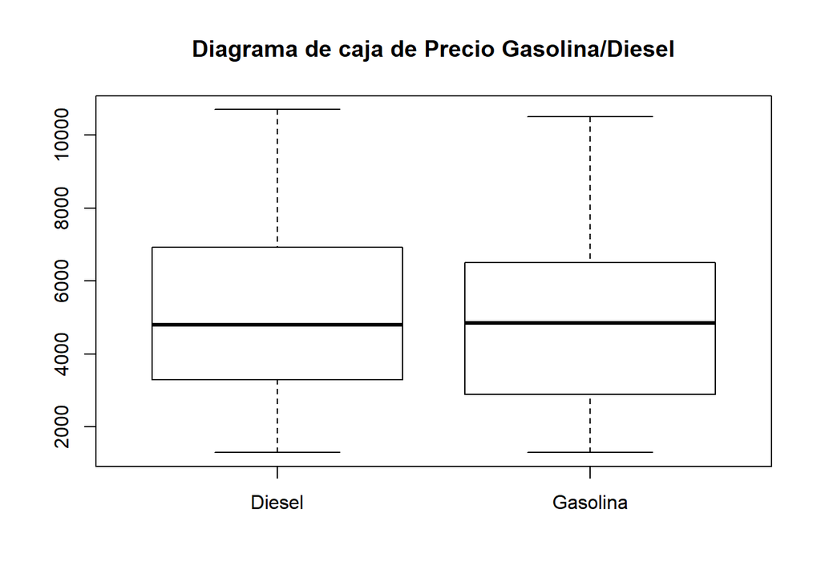

```r
CH_pd <- subset (FAP, Combustible == "D", select = "Precio")
CH_pg <- subset (FAP, Combustible == "G", select = "Precio")
boxplot(CH_pd$Precio,CH_pg$Precio,main="Diagrama de caja de Precio Gasolina/Diesel",names=c("Diesel","Gasolina"))
```

La diferència de mitjanes no serà molt amplia, segons ens indica el diagrama de caixes. Però continuarem amb l’estudi per a certificar-ho:

Apliquem el test no paramètric Mann–Whitney–Wilcoxon per a resoldre el contrast de hipòtesi perquè les variables no presenten una distribuó normal:

```r
wilcox.test(x = CH_pd$Precio, y = CH_pg$Precio, alternative = "two.sided", mu = 0,
            paired = FALSE, conf.int = 0.95)
```

```
##
##  Wilcoxon rank sum test with continuity correction
##
## data:  CH_pd$Precio and CH_pg$Precio
## W = 6859, p-value = 0.3813
## alternative hypothesis: true location shift is not equal to 0
## 95 percent confidence interval:
##  -400 1000
## sample estimates:
## difference in location
##                    300
```

Una vegada aplicat la funció, veiem que el p-value > 0.05, i per tant, no es rebutja la hipòtesi nula. **Conclusió**: NO hi ha diferèncias significativas entre els preus dels vehiles diesel i gasolina.

Fet també observat comparant els diagrames de caixes.

# 2.4.4 Quines variables quantitatives i qualitatives influeixen en el preu?

Estudiarem la relació de les variables quantitatives amb el preu. En concret, de les variables Kilometraje, Potencia i els anys del cotxe.

Realitzem la representació gràfica:

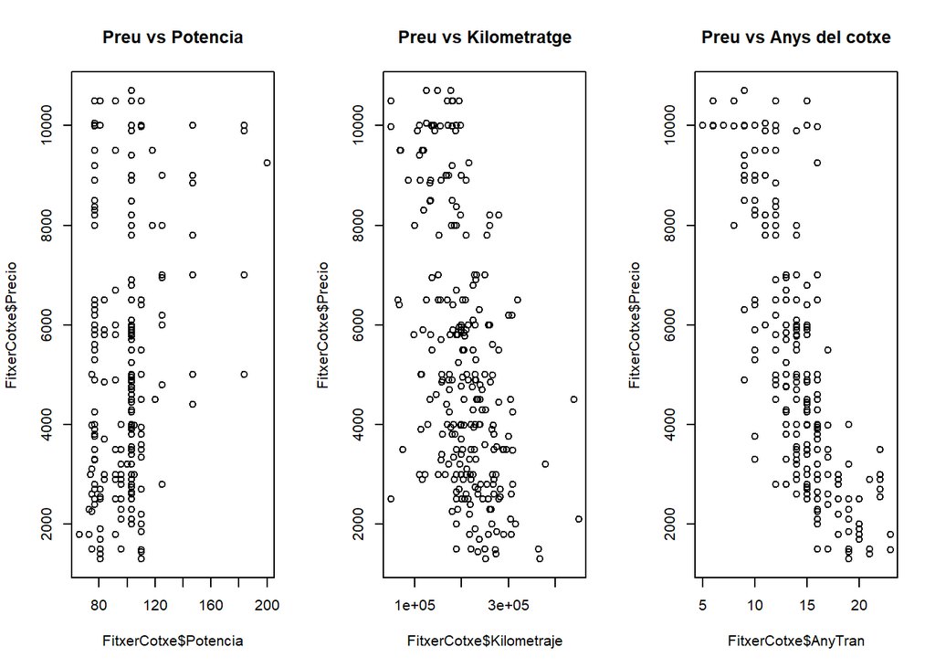

```r
par(mfrow=c(1,3))
plot( FitxerCotxe$Precio ~ FitxerCotxe$Potencia, main="Preu vs Potencia")
plot( FitxerCotxe$Precio ~ FitxerCotxe$Kilometraje, main="Preu vs Kilometratge" )
plot( FitxerCotxe$Precio ~ FitxerCotxe$AnyTran, main="Preu vs Anys del cotxe" )
```

Verifiquem la correlació

```r
cor( FitxerCotxe[,c("Precio","Potencia","Kilometraje","AnyTran")])
```

```
##                 Precio    Potencia Kilometraje     AnyTran
## Precio       1.0000000  0.17755610 -0.48314087 -0.76239059
## Potencia     0.1775561  1.00000000 -0.02629112  0.03144815
## Kilometraje -0.4831409 -0.02629112  1.00000000  0.27850071
## AnyTran     -0.7623906  0.03144815  0.27850071  1.00000000
```

Podem observar que en els cotxes de segona ma A3, aparentment, no influeix tant la potència amb el preu. El que mes influex negativament amb el preu, sóns els anys de antiguetat del cotxe. Amb una correlació negativa >50%, podem indicar que el preu disminuex quant aumenta els anys del cotxe.

El kilometratge influex menys d’un 50 percent, però també podem observar que el preu disminuex si aumenta el kilometratge.

Realitzarem un model de regressió amb les variables quantitatives i qualitatives. I un altre nomès amb les quantitatives. Prèviament, deduim de les correlacions observades, que no hi ha multicolinealitat amb les variables.

```r
Model1<- lm(Precio~AnyTran+Kilometraje+Potencia+Ciudad+Cambio+Combustible, data=FitxerCotxe)
summary(Model1)
```

```
##
## Call:
## lm(formula = Precio ~ AnyTran + Kilometraje + Potencia + Ciudad +
##     Cambio + Combustible, data = FitxerCotxe)
##
## Residuals:
##    Min     1Q Median     3Q    Max
##  -2994   -826      0    816   3803
##
## Coefficients:
##                Estimate Std. Error t value Pr(>|t|)
## (Intercept)   1.306e+04  1.087e+03  12.020  < 2e-16 ***
## AnyTran      -5.112e+02  3.094e+01 -16.525  < 2e-16 ***
## Kilometraje  -1.250e-02  1.595e-03  -7.837 2.28e-13 ***
## Potencia      2.286e+01  4.942e+00   4.626 6.53e-06 ***
## Ciudad02      5.723e+02  1.255e+03   0.456   0.6487
## Ciudad03     -4.558e+02  9.080e+02  -0.502   0.6162
## Ciudad04      9.279e+02  1.054e+03   0.881   0.3795
## Ciudad05      1.718e+03  1.616e+03   1.063   0.2892
## Ciudad06     -2.382e+03  1.608e+03  -1.481   0.1401
## Ciudad07     -4.045e+02  1.135e+03  -0.356   0.7219
## Ciudad08      8.569e+01  8.223e+02   0.104   0.9171
## Ciudad09     -1.320e+03  1.631e+03  -0.810   0.4191
## Ciudad10      4.610e+02  1.250e+03   0.369   0.7127
## Ciudad11     -7.513e+02  1.054e+03  -0.713   0.4767
## Ciudad12      9.542e+02  1.009e+03   0.946   0.3452
## Ciudad13     -5.834e+02  1.606e+03  -0.363   0.7168
## Ciudad15     -5.382e+02  1.065e+03  -0.505   0.6139
## Ciudad17     -6.461e-02  9.767e+02   0.000   0.9999
## Ciudad18     -1.533e+02  1.051e+03  -0.146   0.8841
## Ciudad20     -1.946e+03  1.136e+03  -1.713   0.0881 .
## Ciudad21     -1.360e+02  1.055e+03  -0.129   0.8975
## Ciudad22      1.445e+03  1.585e+03   0.912   0.3629
## Ciudad23     -2.860e+02  1.001e+03  -0.286   0.7753
## Ciudad24      1.492e+03  9.796e+02   1.523   0.1292
## Ciudad25      1.098e+03  1.135e+03   0.967   0.3346
## Ciudad26     -9.238e+02  1.583e+03  -0.584   0.5600
## Ciudad27      1.386e+03  1.249e+03   1.110   0.2683
## Ciudad28      5.633e+02  8.269e+02   0.681   0.4965
## Ciudad29      2.459e+02  9.506e+02   0.259   0.7961
```

[output cut: 10 more lines]

```
## Ciudad42      2.929e+03  1.585e+03   1.848   0.0660 .
## Ciudad43      7.698e+02  9.521e+02   0.808   0.4197
## Ciudad44      2.679e+03  1.580e+03   1.696   0.0914 .
## Ciudad45      5.987e-02  1.000e+03   0.000   1.0000
## Ciudad46      5.663e+01  8.697e+02   0.065   0.9481
## Ciudad48     -2.784e+02  1.004e+03  -0.277   0.7818
## Ciudad50      1.248e+03  9.770e+02   1.278   0.2028
## CambioM      -5.085e+02  2.792e+02  -1.821   0.0700 .
## CombustibleG -9.081e+01  2.477e+02  -0.367   0.7143
## ---
## Signif. codes:  0 '***' 0.001 '**' 0.01 '*' 0.05 '.' 0.1 ' ' 1
##
## Residual standard error: 1367 on 210 degrees of freedom
## Multiple R-squared:  0.7723, Adjusted R-squared:  0.7214
## F-statistic: 15.16 on 47 and 210 DF,  p-value: < 2.2e-16
```

```r
Model2<- lm(Precio~AnyTran+Kilometraje+Potencia, data=FitxerCotxe)
summary(Model2)
```

```
##
## Call:
## lm(formula = Precio ~ AnyTran + Kilometraje + Potencia, data = FitxerCotxe)
##
## Residuals:
##     Min      1Q  Median      3Q     Max
## -3268.0 -1051.7   113.7   925.2  4381.8
##
## Coefficients:
##               Estimate Std. Error t value Pr(>|t|)
## (Intercept)  1.268e+04  6.101e+02  20.780  < 2e-16 ***
## AnyTran     -5.273e+02  2.754e+01 -19.148  < 2e-16 ***
## Kilometraje -1.174e-02  1.475e-03  -7.961 5.69e-14 ***
## Potencia     2.444e+01  4.406e+00   5.547 7.28e-08 ***
## ---
## Signif. codes:  0 '***' 0.001 '**' 0.01 '*' 0.05 '.' 0.1 ' ' 1
##
## Residual standard error: 1433 on 254 degrees of freedom
## Multiple R-squared:  0.6974, Adjusted R-squared:  0.6938
## F-statistic: 195.1 on 3 and 254 DF,  p-value: < 2.2e-16
```

Les tres variables **qualitatives** practicament **NO** influeixen en el preu. De fet nomès mijora el coeficient de determinacio en 3 punts.

Les tres variables **quantitatives** **SI** influeixen en el preu.El p valor és molt petit per a les 3 variables.

#### **Conclusió2**

Les varaibles que mes afecten a la disminució o augment del preu dels A3 de segona ma son les variables quantitatives potència, el kilometratge i anys de antiguetat.

El preu del cotxe augmenta quan es tracta d’un cotxe amb mes potència i disminueix quan es un cotxe mes antic o amb mes kilómetres.

Recordem que es tracta de cotxes de segona ma, i per tant es una conclusió lògica.

# 2.4.5 Predicció amb model de variables quantitatives.

```r
newdata = data.frame(AnyTran = 15, Kilometraje =100000, Potencia=160)
predict(Model2, newdata)
```

```
##        1
## 7504.547
```

#### **Conclusió**

Amb el model realitzat, podem conèixer de manera aproximada quin seria el preu del cotxes de A3 de segona, segons els anys de antiguetat,el kilometratge i la potència.